# **FACTORES QUE INFLUYERON EN EL RENDIMIENTO ACADÉMICO DE LOS ESTUDIANTES DE LA UTEC EN EL PERÍODO 2022-2**

31 Agosto, 2023

### **ESTADÍSTICA Y PROBABILIDADES I**

### “Sección 14 - Grupo 3”

# I. INTRODUCCIÓN

El desempeño académico de un estudiante universitario puede verse afectado por un conjunto de factores en su entorno, el presente estudio se enfoca en la identificación y análisis del impacto de estos factores sobre su desempeño académico, generando información que será útil para la toma de decisiones que contribuyan a mejorar este desempeño.

### - Relevancia:

*Elegimos este tema debido a que es interesante reconocer los factores que influyen en el rendimiento de los estudiantes, al permitir una mejor comprensión de cómo estos pueden afectar de diferentes maneras ya sea, física o psicológicamente en los estudiantes. Asimismo nos puede ayudar en el desarrollo de habilidades y estrategias para mejorar el rendimiento académico y alcanzar los objetivos deseados. Por ello nos gustaría saber si la opinión de los estudiantes de la UTEC a través de una encuesta puede ser útil para la universidad y los educadores para adaptar sus programas y servicios en función de las necesidades de los estudiantes, lo que puede mejorar el desempeño académico de los estudiantes y su bienestar en general.*

# - Objetivo General:

**Analizar los diferentes factores que pueden haber influido en el rendimiento académico de los estudiantes, examinando su impacto, interacción y posibles implicaciones para comprender mejor los determinantes del desempeño estudiantil.**

### - Objetivos Específicos:

-**Determinar si el desarrollo emocional afecta a los estudiantes en su vida universitaria.**

- **Comparar qué factores tienen mayor influencia en el rendimiento académico de los estudiantes universitarios.**
- **Identificar cuál de los dos géneros es más propenso a ser afectado en su rendimiento académico.**
- **Analizar si el nivel socio económico es relevante en el desenvolvimiento académico.**
- **Determinar si la cantidad de horas de estudio está relacionada directamente con las notas.**
- **Analizar si la actividad física está relacionada con el desarrollo académico de los estudiantes.**

## II. DATOS

### Recolección de datos

##### 1. Método de recolección de los datos

La recolección de datos se realizo por medio de una encuesta, ya que no se contaba con una base de datos de lo que queríamos averiguar. Pero también se realizo de esta manera porque es sencillo llegar a una muestra de la población de los estudiantes de la UTEC.

##### 2. Recolección por vía

El medio de vía para realizar la encuesta fue de manera online a través del escaneo del QR y también de manera presencial en la UTEC.

##### 3. Mínimo de personas encuestadas

Se definió un mínimo de 200 encuestas, para que nos quede 150 datos limpios sin tener ningún error.

## III VARIABLES

### 1) Numéricas (8)

#### Continua (5)

| Variable | Definición |
| --- | --- |
| Matemáticas | Promedio final de un curso de matemáticas |
| Ciencias | Promedio final de un curso de ciencias |
| Letras | Promedio final de un curso de letras o humanidades |
| Hora_Estudio | Horas de estudio |
| Asesorias | Horas asesorías |

#### Discreta (3)

[output not shown]

### 2) Categóricas (13)

#### Ordinal (2)

| Variable | Definición |
| --- | --- |
| Motivación | Nivel de motivación académica |
| Economía | Nivel socio-económico |

#### Nominal (11)

[output not shown]

## IV LIMPIEZA DE DATOS

### Consideraciones

- Consideraciones para eliminar observaciones:
  - Observaciones incompletas.
- Consideraciones para el tratamiento de variables:
  - Acortar el nombre de las variables para un manejo de estas mas fácil.
  - Eliminacion columnas que no se utilizaran.
  - Discordancia entre lo que interpreta R y la naturaleza de nuestras variables.

### Intalamos y cargamos las librerias

```r
library("readr")
library("dplyr")
library("tidyverse")
```

```r
library("ggplot2")
```

```r
r <- function(n){
  round(n, 2)
}
```

### Procedimiento de limpieza

1. Leemos los Datos

```r
EC <- read_csv("Encuesta.csv")
```

```
## -------------------------------------------------------- Delimiter: "," chr
## (17): Marca temporal, Nombre de usuario, Sexo, ¿Qué tipo de actividad fí... dbl
## (9): ¿Cuántas veces a la semana dedicaste a hacer actividad física?, ¿C...
```

Después de esto, podemos notar que en nuestra base de datos hay columnas que no nos serán útiles, como la marca de tiempo, la dirección de correo electrónico y una variable que decidimos sacar después de las pruebas porque no sumaba al caso. Para abordar esta situación, procederemos a eliminar estas 2 primeras y 2 ultimas columnas.

```r
EL <- EC[,3:24]
```

2. Revisamos la data.

```r
ncol(EL) # leer el número de columnas / variables.
```

```
## [1] 22
```

```r
nrow(EL) # leer la cantidad de filas / observaciones.
```

```
## [1] 206
```

```r
dim(EL)  # Dimensiones de la base de datos.
```

```
## [1] 206  22
```

```r
str(EL) # Resumen del tipo de variables del base de datos.
```

```
## tibble [206 x 22] (S3: tbl_df/tbl/data.frame)
##  $ Sexo                                                                                                                                                                           : chr [1:206] "Femenino" "Femenino" "Masculino" "Femenino" ...
##  $ ¿Cuántas veces a la semana dedicaste a hacer actividad física?                                                                                                                 : num [1:206] 5 2 1 0 2 2 6 1 0 1 ...
##  $ ¿Qué tipo de actividad física realizaste con mayor frecuencia?                                                                                                                 : chr [1:206] "aeróbico (cardio)" "ambos" "aeróbico (cardio)" "no realizo" ...
##  $ ¿Consideras que tu dieta fue saludable y balanceada?                                                                                                                           : chr [1:206] "si" "si" "si" "si" ...
##  $ ¿Tomas agua frecuentemente?                                                                                                                                                    : chr [1:206] "si" "si" "si" "si" ...
##  $ ¿Consideras que tienes una buena gestión emocional en situaciones difíciles o estresantes?                                                                                     : chr [1:206] "No" "No" "Sí" "Sí" ...
##  $ ¿Cuántos episodios de ansiedad, depresión o estrés has experimentado durante tu vida universitaria?                                                                            : num [1:206] 5 5 1 0 5 3 5 5 5 4 ...
##  $ ¿Te sentiste seguro/a y confiado/a en tu capacidad para lograr tus metas académicas?                                                                                           : chr [1:206] "Sí" "Sí" "Sí" "No" ...
##  $ ¿Crees que tus habilidades sociales fueron suficientes para tu desenvolvimiento en la universidad?                                                                             : chr [1:206] "Sí" "Sí" "Sí" "Sí" ...
##  $ ¿Viviste con tus dos padres durante tu niñez?                                                                                                                                  : chr [1:206] "Solo con 1 de ellos" "Sí" "Sí" "Sí" ...
##  $ ¿Cuánto sacaste de promedio final en tu último curso de matemáticas? ejemplo: cálculo de una variable, cálculo vectorial, etc (usar el punto como separador decimal)           : num [1:206] 15 14.8 16 15 14.5 14.6 13 16 11 19 ...
##  $ ¿Cuánto sacaste de promedio final en tu último curso de ciencias?  ejemplo: Quimica general, ciencia de los materiales, etc.(usar el punto como separador decimal)             : num [1:206] 14.5 17.8 18 15 13.8 13 13 16 11 15 ...
##  $ ¿Cuánto sacaste de promedio final en tu último curso de letras o humanidades? ejemplo: comunicación 1, Proyecto interdisciplinario, etc. (usar el punto como separador decimal): num [1:206] 18 16 17 17 16 17.5 16 15 18 18 ...
##  $ ¿Cuántas horas a la semana estudiaste fuera del horario de la clase?                                                                                                           : num [1:206] 9 9 4.5 4.5 4.5 4.5 18 18 4.5 4.5 ...
##  $ ¿Cuántas horas a la semana asististe a asesorías?                                                                                                                              : num [1:206] 3.5 2.5 1.5 3.5 2.5 0.5 3.5 2.5 0.5 2.5 ...
##  $ ¿Cómo calificas el servicio de asesoría académica en tu universidad? (0=bajo, 5=alto)                                                                                          : num [1:206] 3 4 4 4 2 2 5 3 2 3 ...
##  $ ¿Prefieres estudiar solo o en grupo?                                                                                                                                           : chr [1:206] "Solo" "Solo" "En grupo" "En grupo" ...
##  $ ¿En qué momento del día te sientes más productivo/a para estudiar?                                                                                                             : chr [1:206] "Noche" "Noche" "Noche" "Tarde" ...
##  $ Nivel de motivación académica                                                                                                                                                  : chr [1:206] NA NA "Alto" "Medio" ...
##  $ ¿Cuál es tu nivel socio-económico?                                                                                                                                             : chr [1:206] "media" "baja" "media" "media" ...
##  $ ¿Cómo financias tus estudios?                                                                                                                                                  : chr [1:206] "beca" "beca" "beca" "beca" ...
##  $ ¿Qué tipo de educación has recibido?                                                                                                                                           : chr [1:206] "Estatal" "Estatal" "Estatal" "Privada" ...
```

```r
summary(EL) # Resumen general de la base de datos.
```

```
##      Sexo
##  Length:206
##  Class :character
##  Mode  :character
##
##
##
##  ¿Cuántas veces a la semana dedicaste a hacer actividad física?
##  Min.   :0.000
##  1st Qu.:1.000
##  Median :2.000
##  Mean   :2.408
##  3rd Qu.:4.000
##  Max.   :6.000
##  ¿Qué tipo de actividad física realizaste con mayor frecuencia?
##  Length:206
##  Class :character
##  Mode  :character
##
##
##
##  ¿Consideras que tu dieta fue saludable y balanceada?
##  Length:206
##  Class :character
##  Mode  :character
##
##
##
##  ¿Tomas agua frecuentemente?
##  Length:206
##  Class :character
##  Mode  :character
##
##
##
##  ¿Consideras que tienes una buena gestión emocional en situaciones difíciles o estresantes?
##  Length:206
##  Class :character
##  Mode  :character
##
```

[output cut: 85 more lines]

```
##
##  Nivel de motivación académica ¿Cuál es tu nivel socio-económico?
##  Length:206                    Length:206
##  Class :character              Class :character
##  Mode  :character              Mode  :character
##
##
##
##  ¿Cómo financias tus estudios? ¿Qué tipo de educación has recibido?
##  Length:206                    Length:206
##  Class :character              Class :character
##  Mode  :character              Mode  :character
##
##
##
```

3. Revisamos el inicio y el final.

```r
head(EL) #lee las primeras filas de la base de datos
```

```
## # A tibble: 6 x 22
##   Sexo      ¿Cuántas veces a la ~1 ¿Qué tipo de activid~2 ¿Consideras que tu d~3
##   <chr>                      <dbl> <chr>                  <chr>
## 1 Femenino                       5 aeróbico (cardio)      si
## 2 Femenino                       2 ambos                  si
## 3 Masculino                      1 aeróbico (cardio)      si
## 4 Femenino                       0 no realizo             si
## 5 Masculino                      2 anaeróbico (de fuerza) si
## 6 Femenino                       2 ambos                  no
## # i abbreviated names:
## #   1: `¿Cuántas veces a la semana dedicaste a hacer actividad física?`,
## #   2: `¿Qué tipo de actividad física realizaste con mayor frecuencia?`,
## #   3: `¿Consideras que tu dieta fue saludable y balanceada?`
## # i 18 more variables: `¿Tomas agua frecuentemente?` <chr>,
## #   `¿Consideras que tienes una buena gestión emocional en situaciones difíciles o estresantes?` <chr>,
## #   `¿Cuántos episodios de ansiedad, depresión o estrés has experimentado durante tu vida universitaria?` <dbl>, ...
```

```r
tail(EL) #lee las últimas filas de la base de datos
```

```
## # A tibble: 6 x 22
##   Sexo      ¿Cuántas veces a la ~1 ¿Qué tipo de activid~2 ¿Consideras que tu d~3
##   <chr>                      <dbl> <chr>                  <chr>
## 1 Femenino                       2 aeróbico (cardio)      no
## 2 Masculino                      6 ambos                  si
## 3 Masculino                      0 no realizo             no
## 4 Femenino                       1 aeróbico (cardio)      no
## 5 Masculino                      4 anaeróbico (de fuerza) si
## 6 Masculino                      1 anaeróbico (de fuerza) no
## # i abbreviated names:
## #   1: `¿Cuántas veces a la semana dedicaste a hacer actividad física?`,
## #   2: `¿Qué tipo de actividad física realizaste con mayor frecuencia?`,
## #   3: `¿Consideras que tu dieta fue saludable y balanceada?`
## # i 18 more variables: `¿Tomas agua frecuentemente?` <chr>,
## #   `¿Consideras que tienes una buena gestión emocional en situaciones difíciles o estresantes?` <chr>,
## #   `¿Cuántos episodios de ansiedad, depresión o estrés has experimentado durante tu vida universitaria?` <dbl>, ...
```

Como observamos que la data no esta limpia del todo procedemos a hacer la limpieza

- Hallamos los Datos Completos/Incompletos

```r
sum(is.na(EL)) #is.na() -> este comando detecta los datos incompletos; sum -> sumar
```

```
## [1] 2
```

```r
#Sumar la cantidad de datos incompletos
sum(!is.na(EL)) #!is.na() -> es la negación de is.na, es decir, indica los datos completos.
```

```
## [1] 4530
```

Eliminamos las filas con variables incompletas.

```r
EL <- EL[-1,] # se encuentra en la primera fila
EL <- EL[-1,]
```

```r
sum(is.na(EL))
```

```
## [1] 0
```

```r
sum(!is.na(EL))
```

```
## [1] 4488
```

Esas dos filas con datos incompletos provienen de las pruebas realizadas.

Usamos el is.na, el is.na identifica las casillas vacías en todo el data, para saber la cantidad total de datos faltantes se usar el comando sum(is.na()).

- Hallar Casos Completos/Incompletos

Un caso completo hace referencia a una observación con todas las celdas completas; es decir un individuo que ha respondido a todas las variables.

complete.cases

```r
sum(complete.cases(EL)) #complete.cases -> casos completos
```

```
## [1] 204
```

```r
sum(!complete.cases(EL))#!complete.cases -> casos incompletos
```

```
## [1] 0
```

Verificamos el porcentaje de casos incompletos de EL

```r
round(sum(!complete.cases(EL))/nrow(EL)*100)
```

```
## [1] 0
```

## Porcentaje de casos completos de EC

```r
round(sum(complete.cases(EL))/nrow(EL)*100)
```

```
## [1] 100
```

Renombrados las variables para hacerlas mas manejables:

**Usamos el comando Rename para que no haya errores de escritura en los nombres de columna**

```r
names(EL)
```

```
##  [1] "Sexo"
##  [2] "¿Cuántas veces a la semana dedicaste a hacer actividad física?"
##  [3] "¿Qué tipo de actividad física realizaste con mayor frecuencia?"
##  [4] "¿Consideras que tu dieta fue saludable y balanceada?"
##  [5] "¿Tomas agua frecuentemente?"
##  [6] "¿Consideras que tienes una buena gestión emocional en situaciones difíciles o estresantes?"
##  [7] "¿Cuántos episodios de ansiedad, depresión o estrés has experimentado durante tu vida universitaria?"
##  [8] "¿Te sentiste seguro/a y confiado/a en tu capacidad para lograr tus metas académicas?"
##  [9] "¿Crees que tus habilidades sociales fueron suficientes para tu desenvolvimiento en la universidad?"
## [10] "¿Viviste con tus dos padres durante tu niñez?"
## [11] "¿Cuánto sacaste de promedio final en tu último curso de matemáticas? ejemplo: cálculo de una variable, cálculo vectorial, etc (usar el punto como separador decimal)"
## [12] "¿Cuánto sacaste de promedio final en tu último curso de ciencias?  ejemplo: Quimica general, ciencia de los materiales, etc.(usar el punto como separador decimal)"
## [13] "¿Cuánto sacaste de promedio final en tu último curso de letras o humanidades? ejemplo: comunicación 1, Proyecto interdisciplinario, etc. (usar el punto como separador decimal)"
## [14] "¿Cuántas horas a la semana estudiaste fuera del horario de la clase?"
## [15] "¿Cuántas horas a la semana asististe a asesorías?"
## [16] "¿Cómo calificas el servicio de asesoría académica en tu universidad? (0=bajo, 5=alto)"
## [17] "¿Prefieres estudiar solo o en grupo?"
## [18] "¿En qué momento del día te sientes más productivo/a para estudiar?"
## [19] "Nivel de motivación académica"
## [20] "¿Cuál es tu nivel socio-económico?"
## [21] "¿Cómo financias tus estudios?"
## [22] "¿Qué tipo de educación has recibido?"
```

- Renombrar a nuestras variables.

```r
EL=rename(EL,Género="Sexo",AFísica="¿Cuántas veces a la semana dedicaste a hacer actividad física?" ,FrecuenciaA="¿Qué tipo de actividad física realizaste con mayor frecuencia?",Dieta="¿Consideras que tu dieta fue saludable y balanceada?",TAgua="¿Tomas agua frecuentemente?",Emocional="¿Consideras que tienes una buena gestión emocional en situaciones difíciles o estresantes?",Episodios="¿Cuántos episodios de ansiedad, depresión o estrés has experimentado durante tu vida universitaria?",Capacidad="¿Te sentiste seguro/a y confiado/a en tu capacidad para lograr tus metas académicas?" ,Habilidades="¿Crees que tus habilidades sociales fueron suficientes para tu desenvolvimiento en la universidad?",Vivir="¿Viviste con tus dos padres durante tu niñez?",Matemáticas="¿Cuánto sacaste de promedio final en tu último curso de matemáticas? ejemplo: cálculo de una variable, cálculo vectorial, etc (usar el punto como separador decimal)" ,Ciencias="¿Cuánto sacaste de promedio final en tu último curso de ciencias?  ejemplo: Quimica general, ciencia de los materiales, etc.(usar el punto como separador decimal)" ,Letras="¿Cuánto sacaste de promedio final en tu último curso de letras o humanidades? ejemplo: comunicación 1, Proyecto interdisciplinario, etc. (usar el punto como separador decimal)",Hora_Estudio= "¿Cuántas horas a la semana estudiaste fuera del horario de la clase?" ,Asesorias="¿Cuántas horas a la semana asististe a asesorías?",Servicios="¿Cómo calificas el servicio de asesoría académica en tu universidad? (0=bajo, 5=alto)",Estudia="¿Prefieres estudiar solo o en grupo?",Productivo="¿En qué momento del día te sientes más productivo/a para estudiar?" ,Motivación= "Nivel de motivación académica" ,Economía="¿Cuál es tu nivel socio-económico?",Financia="¿Cómo financias tus estudios?",TEducación="¿Qué tipo de educación has recibido?" )
```

Verificamos que todo:

```r
names(EL)
```

```
##  [1] "Género"       "AFísica"      "FrecuenciaA"  "Dieta"        "TAgua"
##  [6] "Emocional"    "Episodios"    "Capacidad"    "Habilidades"  "Vivir"
## [11] "Matemáticas"  "Ciencias"     "Letras"       "Hora_Estudio" "Asesorias"
## [16] "Servicios"    "Estudia"      "Productivo"   "Motivación"   "Economía"
## [21] "Financia"     "TEducación"
```

Convertimos las variables al tipo de dato deseado

```r
EL$Letras= as.numeric(EL$Letras)
```

```r
EL$AFísica=as.integer(EL$AFísica)
```

```r
EL$Episodios=as.integer(EL$Episodios)
```

```r
EL$Servicios=as.integer(EL$Servicios)
```

Verificamos que todas las variables están bien interpretadas por R

```r
str(EL)
```

```
## tibble [204 x 22] (S3: tbl_df/tbl/data.frame)
##  $ Género      : chr [1:204] "Masculino" "Femenino" "Masculino" "Femenino" ...
##  $ AFísica     : int [1:204] 1 0 2 2 6 1 0 1 6 2 ...
##  $ FrecuenciaA : chr [1:204] "aeróbico (cardio)" "no realizo" "anaeróbico (de fuerza)" "ambos" ...
##  $ Dieta       : chr [1:204] "si" "si" "si" "no" ...
##  $ TAgua       : chr [1:204] "si" "si" "si" "si" ...
##  $ Emocional   : chr [1:204] "Sí" "Sí" "No" "Sí" ...
##  $ Episodios   : int [1:204] 1 0 5 3 5 5 5 4 0 5 ...
##  $ Capacidad   : chr [1:204] "Sí" "No" "Sí" "No" ...
##  $ Habilidades : chr [1:204] "Sí" "Sí" "No" "No" ...
##  $ Vivir       : chr [1:204] "Sí" "Sí" "Sí" "Sí" ...
##  $ Matemáticas : num [1:204] 16 15 14.5 14.6 13 16 11 19 17 15 ...
##  $ Ciencias    : num [1:204] 18 15 13.8 13 13 16 11 15 17 14 ...
##  $ Letras      : num [1:204] 17 17 16 17.5 16 15 18 18 16 18 ...
##  $ Hora_Estudio: num [1:204] 4.5 4.5 4.5 4.5 18 18 4.5 4.5 18 18 ...
##  $ Asesorias   : num [1:204] 1.5 3.5 2.5 0.5 3.5 2.5 0.5 2.5 1.5 2.5 ...
##  $ Servicios   : int [1:204] 4 4 2 2 5 3 2 3 3 3 ...
##  $ Estudia     : chr [1:204] "En grupo" "En grupo" "Solo" "Solo" ...
##  $ Productivo  : chr [1:204] "Noche" "Tarde" "Madrugada/día" "Noche" ...
##  $ Motivación  : chr [1:204] "Alto" "Medio" "Medio" "Medio" ...
##  $ Economía    : chr [1:204] "media" "media" "media" "media" ...
##  $ Financia    : chr [1:204] "beca" "beca" "mis padres me apoyan" "beca" ...
##  $ TEducación  : chr [1:204] "Estatal" "Privada" "Privada" "Estatal" ...
```

# V ANÁLISIS DESCRIPTIVO

## **Determinar si el desarrollo emocional afecta a los estudiantes en su desempeño académico(promedio de notas).**

```r
EL$Notas_promedio=(EL$Letras+EL$Matemáticas+EL$Ciencias)/3
```

Creamos una columna que sera el promedio aritmético de la notas de matemática, ciencias y letras.

```r
EL$Notas_promedio=(EL$Letras+EL$Matemáticas+EL$Ciencias)/3
```

##### Gráfico N°1

Mediante esta gráfica lograremos observar la relación entre el promedio de notas y desarrollo emocional que genero haber vivido con tus padres en la infancia.

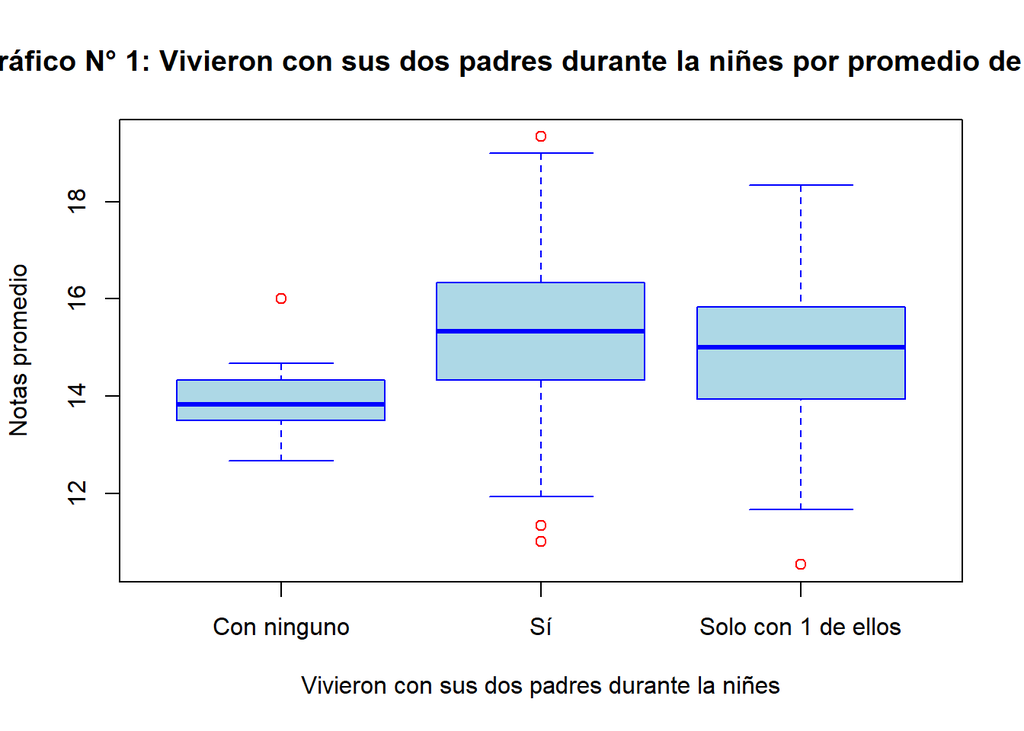

```r
# Personalización del boxplot
boxplot(EL$Notas_promedio ~ EL$Vivir,
        main = "Gráfico N° 1: Vivieron con sus dos padres durante la niñes por promedio de notas",
        xlab = "Vivieron con sus dos padres durante la niñes",
        ylab = "Notas promedio",
        col = "lightblue",
        outcol = "red",
        border = "blue")
```

Se puede observar que la variabilidad del promedio de notas de las personas que crecieron sin ningún padre es poca en comparación con los alumnos que vivieron con uno de sus padres o los dos y a su ves la mediana es mas baja. También podemos ver el valor exacto de las medianas de cada variable y corroborar.

```r
fila_con_dos_padres <- EL[EL$Vivir == "Sí", ]
fila_con_un_padre <- EL[EL$Vivir == "Solo con 1 de ellos", ]
fila_sin_padres <- EL[EL$Vivir == "Con ninguno", ]
```

```r
Notas_promedio_con_dos_padres <- median(fila_con_dos_padres$Notas_promedio)
Notas_promedio_con_dos_padres
```

```
## [1] 15.33333
```

```r
Notas_promedio_con_un_padre <- median(fila_con_un_padre$Notas_promedio)
Notas_promedio_con_un_padre
```

```
## [1] 15
```

```r
Notas_promedio_sin_padres <- median(fila_sin_padres$Notas_promedio)
Notas_promedio_sin_padres
```

```
## [1] 13.83333
```

##### Gráfico caja N°2

En este gráfico no podemos observar que el numero de episodios de ansiedad tenga relación significante con el promedio de notas

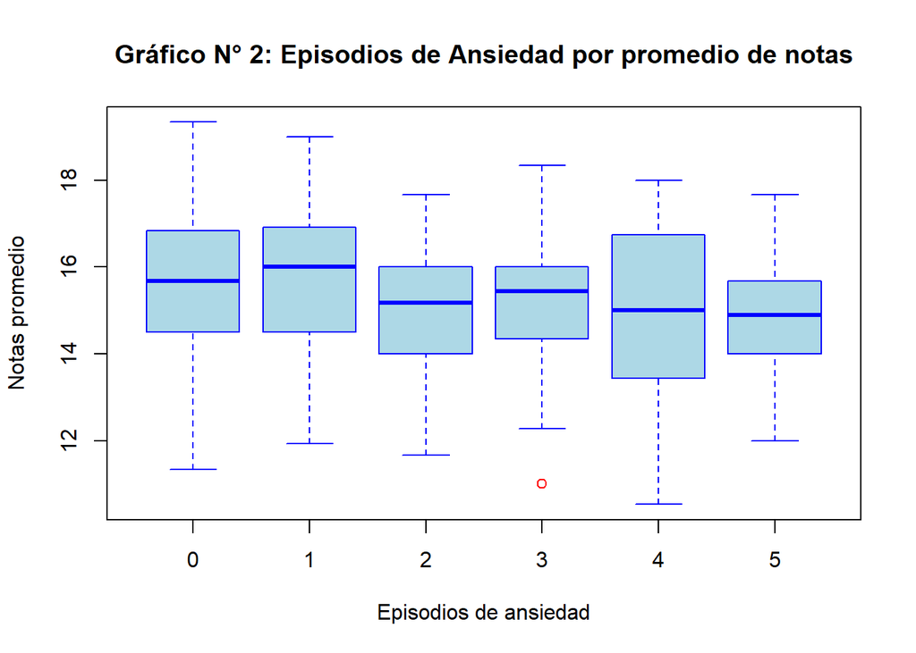

```r
# Personalización del boxplot
boxplot(EL$Notas_promedio ~ EL$Episodios,
        main = "Gráfico N° 2: Episodios de Ansiedad por promedio de notas",
        xlab = "Episodios de ansiedad",
        ylab = "Notas promedio",
        col = "lightblue",
        outcol = "red",
        border = "blue")
```

##### Gráfico caja N°3

En esta gráfica se puede observar que los alumnos que consideran tener mejor gestión emocional tienen una ligera mejora en su pu promedio de notas

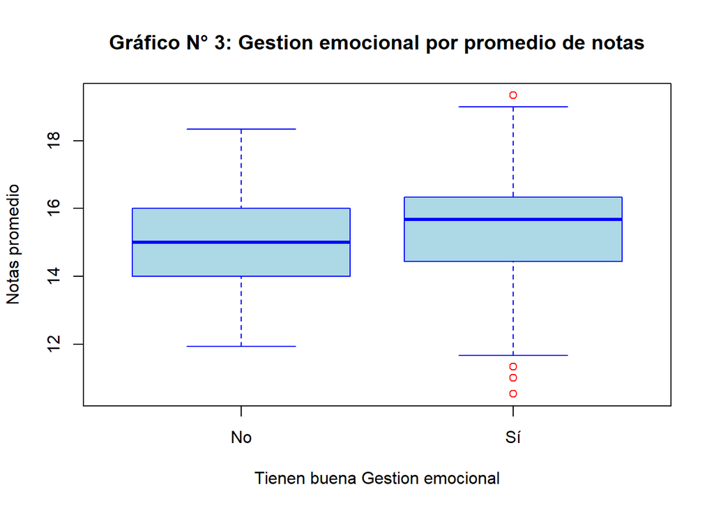

```r
# Personalización del boxplot
boxplot(EL$Notas_promedio ~ EL$Emocional,
        main = "Gráfico N° 3: Gestion emocional por promedio de notas",
        xlab = "Tienen buena Gestion emocional",
        ylab = "Notas promedio",
        col = "lightblue",
        outcol = "red",
        border = "blue")
```

##### Gráfico caja N°4

La mediana de los alumnos que consideran tener la capacidades suficientes para lograr obtener las notas que quieren tienen poca diferencia con el grupo que no, pero del grupo que confía en sus capacidades tiene un rango de promedio de notas que tiende a tener buenas notas en comparación de los que no consideran tener la capacidades suficientes.

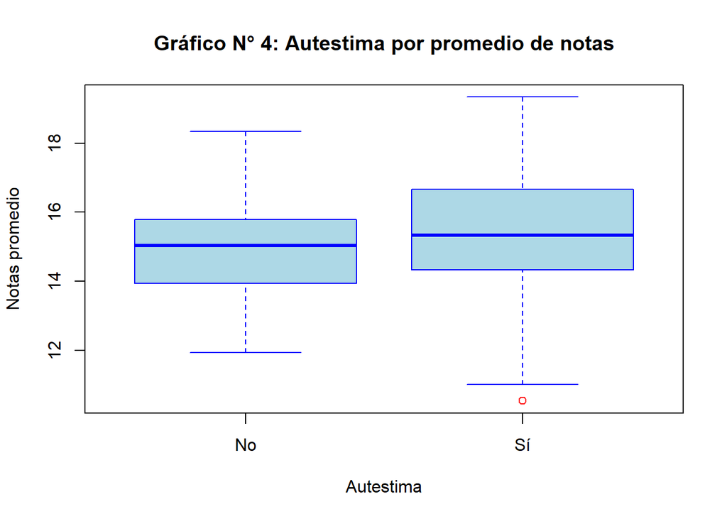

```r
# Personalización del boxplot
boxplot(EL$Notas_promedio ~ EL$Capacidad,
        main = "Gráfico N° 4: Autestima por promedio de notas",
        xlab = "Autestima",
        ylab = "Notas promedio",
        col = "lightblue",
        outcol = "red",
        border = "blue")
```

##### Gráfico caja N°5

De este gráfico se puede deducir que los alumnos que consideran tener las habilidades sociales necesarias para poder desempeñarse bien el lo académico tienen una ligera mejora el el promedio de notas en comparación con los alumnos que no consideran que sus habilidades sociales fueron suficientes para un buen desempeño. A su vez la variabilidad del promedio de notas del grupo que considera tener habilidades sociales suficientes es menor que la del grupo que no considera tener habilidades sociales suficientes.

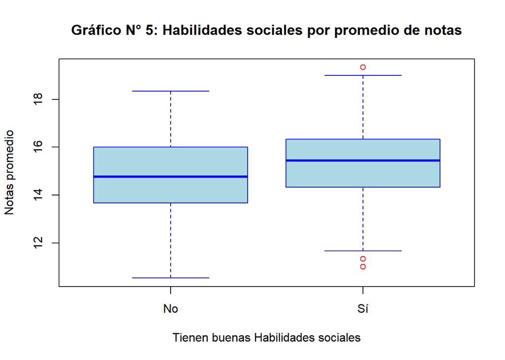

```r
# Personalización del boxplot
boxplot(EL$Notas_promedio ~ EL$Habilidades,
        main = "Gráfico N° 5: Habilidades sociales por promedio de notas",
        xlab = "Tienen buenas Habilidades sociales",
        ylab = "Notas promedio",
        col = "lightblue",
        outcol = "red",
        border = "blue")
```

## **Analizar si el nivel socio económico es relevante en el desenvolvimiento académico.**

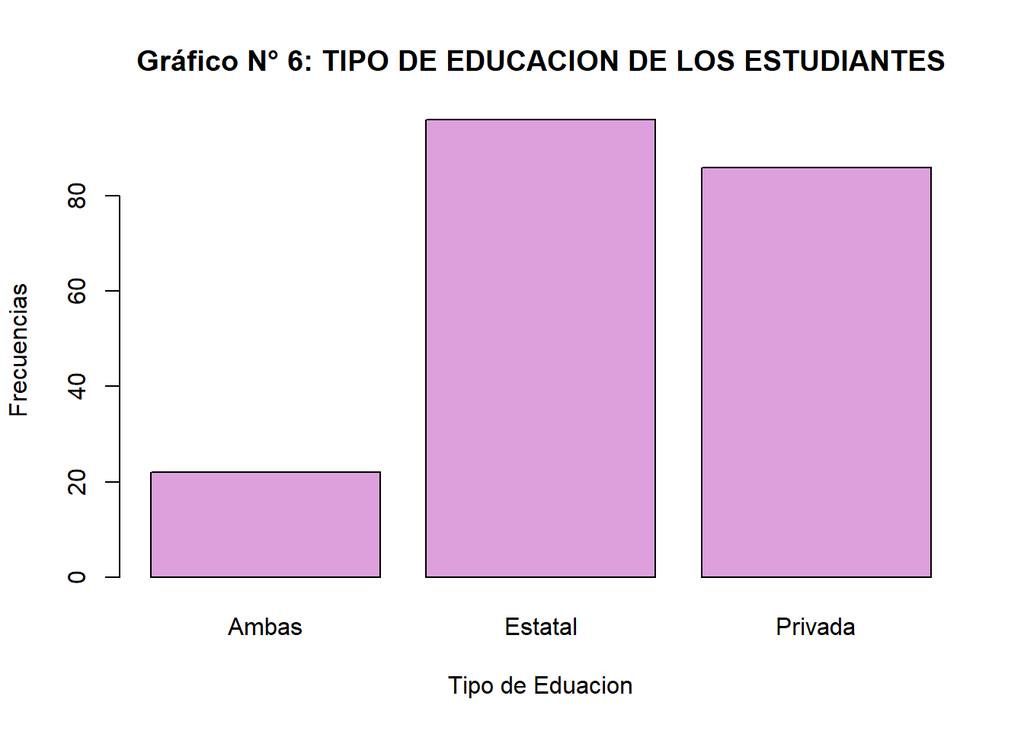

```r
barplot(table(EL$TEducación), col=c("#DDA0DD"),main = "Gráfico N° 6: TIPO DE EDUCACION DE LOS ESTUDIANTES", xlab = "Tipo de Eduacion", ylab = "Frecuencias")
```

```r
EL %>% count(EL$TEducación) %>% arrange(desc(n)) # %>% slice(1)
```

```
## # A tibble: 3 x 2
##   `EL$TEducación`     n
##   <chr>           <int>
## 1 Estatal            96
## 2 Privada            86
## 3 Ambas              22
```

```r
Tabla6 <- table(EL$TEducación)
porcentaje <- r(prop.table(Tabla6) * 100)
print(porcentaje)
```

```
##
##   Ambas Estatal Privada
##   10.78   47.06   42.16
```

##### Gráfico caja N°7

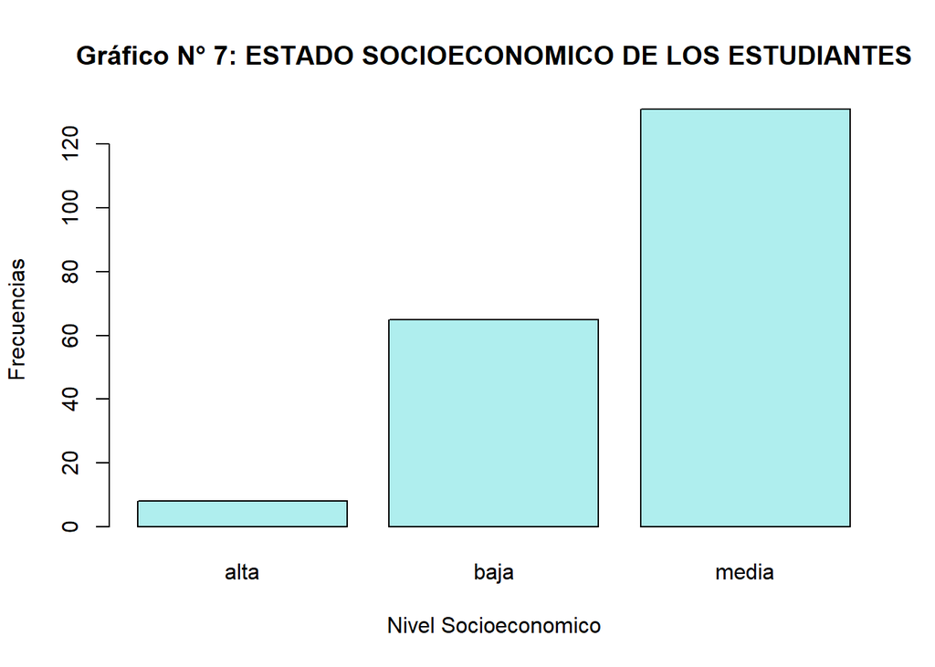

```r
barplot(table(EL$Economía), col=c("#AFEEEE"),main = "Gráfico N° 7: ESTADO SOCIOECONOMICO DE LOS ESTUDIANTES", xlab = "Nivel Socioeconomico", ylab = "Frecuencias")
```

```r
EL %>% count(EL$Economía) %>% arrange(desc(n))
```

```
## # A tibble: 3 x 2
##   `EL$Economía`     n
##   <chr>         <int>
## 1 media           131
## 2 baja             65
## 3 alta              8
```

```r
Tabla4 <- table(EL$Economía)
porcentaje <- r(prop.table(Tabla4) * 100)
print(porcentaje)
```

```
##
##  alta  baja media
##  3.92 31.86 64.22
```

#### Como resultado nos dió que…

El diagrama de barras de nivel socio económico nos permite examinar la distribución de los estudiantes según su posición socio económica y clasificarlos en diferentes niveles como, bajo, medio y alto.

##### Gráfico caja N°8

```r
Tabla5 <- table(EL$Financia)
porcentaje <- r(prop.table(Tabla5) * 100)
print(porcentaje)
```

```
##
##     ayuda financiera                 beca mis padres me apoyan
##                 4.90                58.82                34.80
##              trabajo
##                 1.47
```

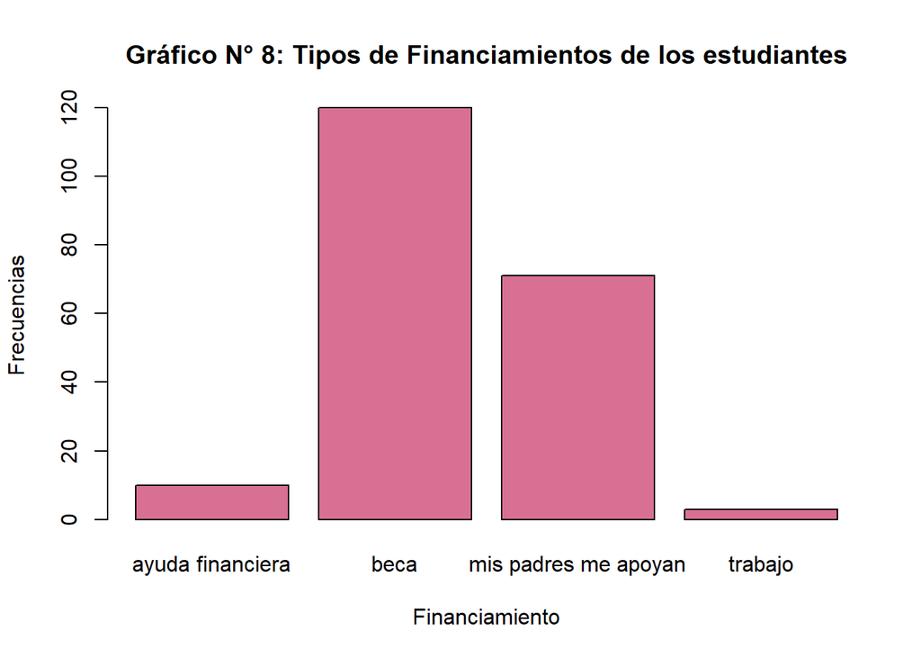

```r
barplot(Tabla5, col=c("#D87093"),main = "Gráfico N° 8: Tipos de Financiamientos de los estudiantes", xlab = "Financiamiento", ylab = "Frecuencias")
```

```r
EL %>% count(EL$Financia) %>% arrange(desc(n))
```

```
## # A tibble: 4 x 2
##   `EL$Financia`            n
##   <chr>                <int>
## 1 beca                   120
## 2 mis padres me apoyan    71
## 3 ayuda financiera        10
## 4 trabajo                  3
```

```r
Tabla5 <- table(EL$Financia)
porcentaje <- r(prop.table(Tabla5) * 100)
print(porcentaje)
```

```
##
##     ayuda financiera                 beca mis padres me apoyan
##                 4.90                58.82                34.80
##              trabajo
##                 1.47
```

##### Gráfico caja N°9

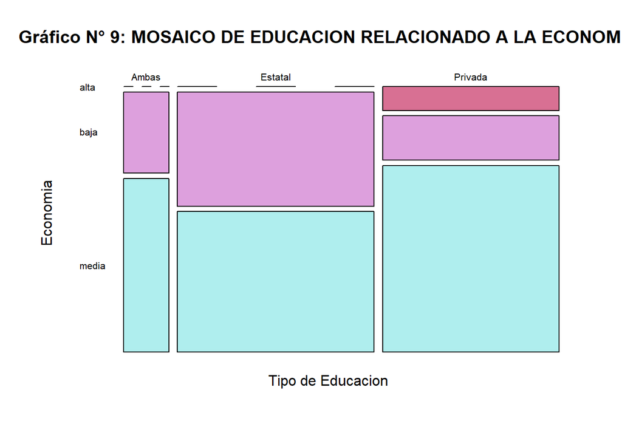

```r
colorsitos <-c("#D87093","#DDA0DD","#AFEEEE")
mosaicplot(EL$TEducación~EL$Economía,las=1,col= colorsitos ,main = "Gráfico N° 9: MOSAICO DE EDUCACION RELACIONADO A LA ECONOMIA", xlab = "Tipo de Educacion", ylab = "Economia")
```

Según este mosaico se puedes obtener las siguiente conclusiones: Las lineas cortadas significan que no hay datos en ese bloque, ya que se asume que aquellos que pertenecen a una economía alta no optan por la educación estatal, y la economía media y baja son las que se presentan en mayor proporción para optar por una educación estatal. - Desfase en el tiempo ya que el tipo de Educación esta dado en un tiempo pasado y la tipo de economía esta regido en el presente

##### Gráfico caja N°10

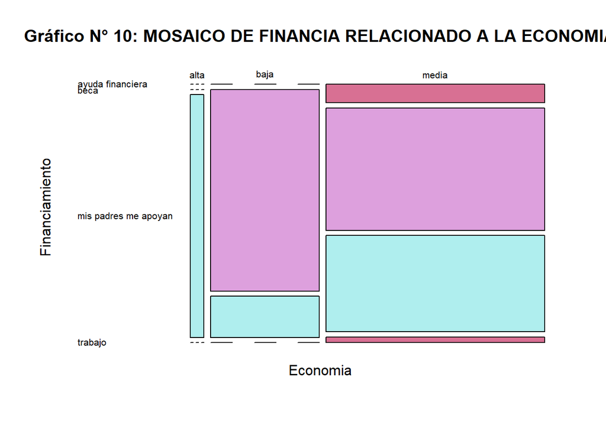

```r
colors <- c("#D87093","#DDA0DD","#AFEEEE")
mosaicplot(EL$Economía~EL$Financia,
           las=1,col= colors,main = "Gráfico N° 10: MOSAICO DE FINANCIA RELACIONADO A LA ECONOMIA",
           xlab = "Economia",
           ylab = "Financiamiento")
```

Según el mosaico presentado se observa que no hay estudiantes de nivel económico alto que tengan ayuda financiera y tampoco cuenten con una beca, ademas también se lograr divisar que tampoco hay estudiantes de nivel económico alto que trabajen. Asimismo no hay estudiantes de Nivel bajo que tengan ayuda financiera y que tampoco trabajen. Este dado resultado es sorprendente por que se esperaría que aquellos que pertenecen a un nivel Socio económico bajo trabajasen, sin embargo, no es el caso que se presenta.

##### Gráfico caja N°11

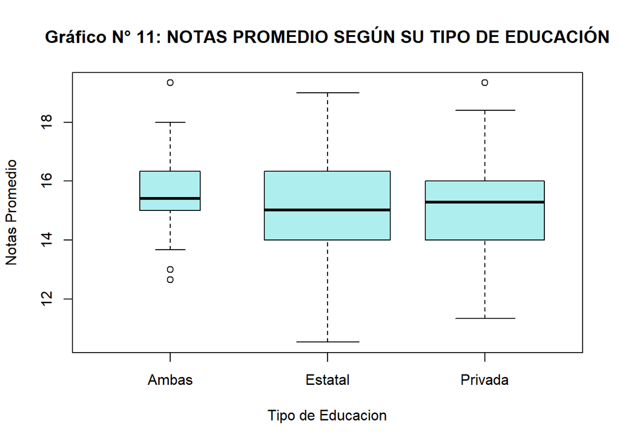

```r
colores <-c("#AFEEEE")
boxplot(EL$Notas_promedio~EL$TEducación,
        col=colores,
        varwidth=TRUE,
        main = "Gráfico N° 11: NOTAS PROMEDIO SEGÚN SU TIPO DE EDUCACIÓN",
           xlab = "Tipo de Educacion",
           ylab = "Notas Promedio")
```

De esta gráfica se puede concluir que la variable Tipo de Educación no tiene mucho que influir en las notas promedio de los estudiantes debido a que las medianas de estas, están parcialmente semejantes, por lo que no se logra apreciar un cambio significativo.

##### Gráfico caja N°12

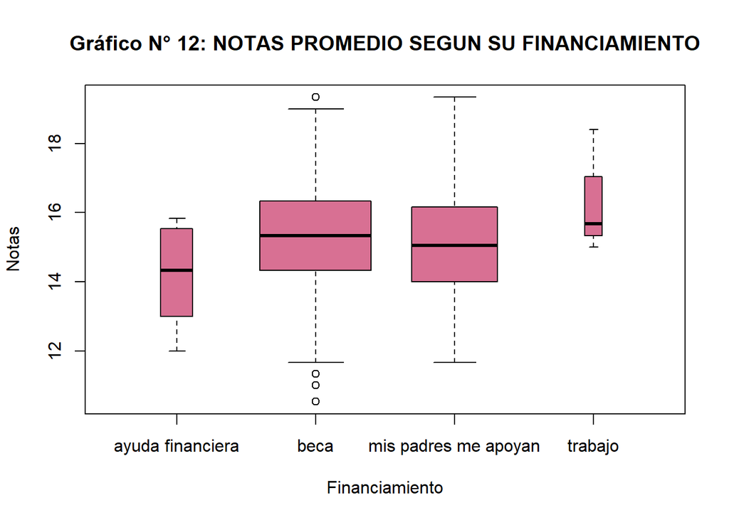

```r
loscolores <- c("#D87093")
boxplot(EL$Notas_promedio~EL$Financia,
        col= loscolores,
        varwidth=TRUE,
        main = "Gráfico N° 12: NOTAS PROMEDIO SEGUN SU FINANCIAMIENTO",
           xlab = "Financiamiento",
           ylab = "Notas")
```

```r
median(EL$Notas_promedio)
```

```
## [1] 15.33333
```

A partir de este Diagrama de caja y bigotes podemos plantear una hipótesis, que aquellos que trabajan, llevan menos cursos y por ende sacan mejores notas. Ya que se logra apreciar un cambio considerable en las notas a comparación de quienes cuentan con una ayuda financiera, beca o apoyo familiar, prácticamente los que trabajan sacan mejores notas a comparación del resto, teniendo una nota promedio a partir de 15. Por otro lado los que reciben ayuda financiera son los que sacan menores notas.

Otro dato interesante, es de la variable Financiamiento si tiene mucho que influir en las notas promedio de los estudiantes, ya que al observar las medianas de las diferentes cajas se lograr apreciar una diferencia bastante considerable, quienes trabajan son los que obtienen mejores notas según nuestra base de datos.

##### Gráfico caja N°13

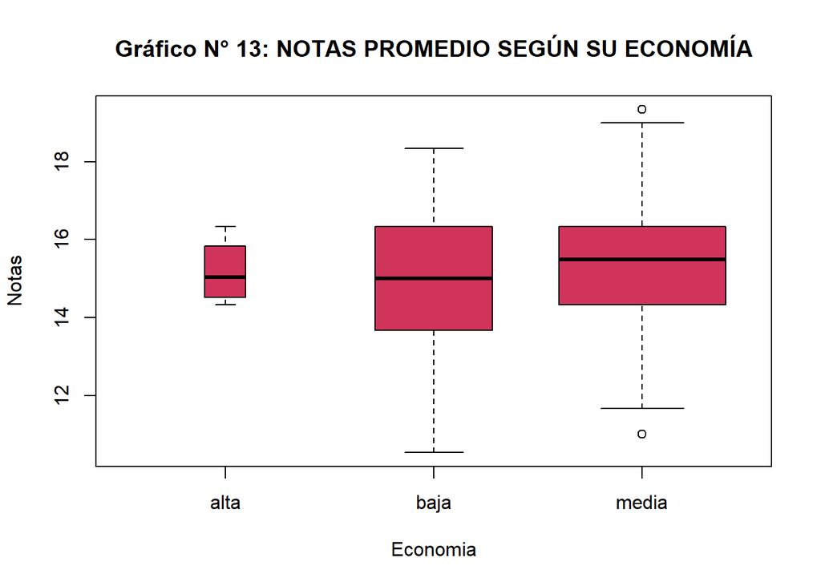

```r
boxplot(EL$Notas_promedio~EL$Economía, col="#d1345b",
        varwidth=TRUE,
        main = "Gráfico N° 13: NOTAS PROMEDIO SEGÚN SU ECONOMÍA",
           xlab = "Economia",
           ylab = "Notas")
```

Del diagrama de cajas y bigotes se logra apreciar que los que pertenecen a una economía alta son reducidos a comparación de resto, sin embargo las notas promedio de las distintas clases socio económicas son medianamente similares, lo que se concluye que la variable Economía no tiene mucho que influir en las Notas Promedio de los estudiantes.

##### Gráfico caja N°14

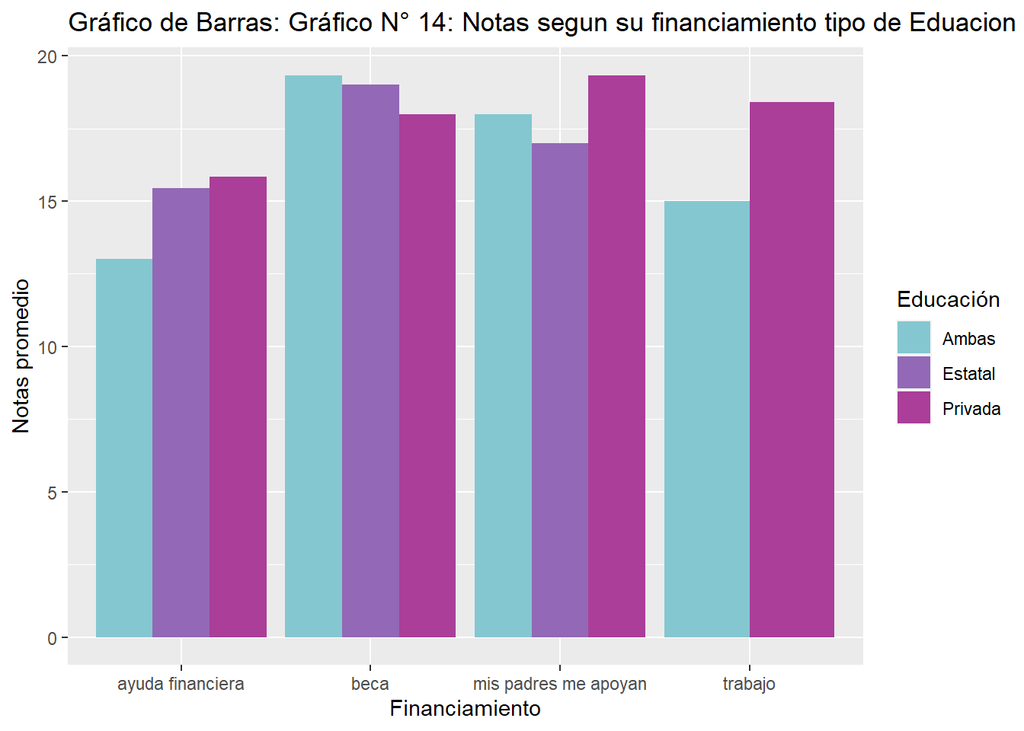

```r
ggplot(EL, aes(x = Financia, y = Notas_promedio, fill = TEducación)) +
  geom_col(position = "dodge")+labs(title = "Gráfico de Barras: Gráfico N° 14: Notas segun su financiamiento tipo de Eduacion ", x = "Financiamiento", y = "Notas promedio")+scale_fill_manual(values = c("#84c7d0", "#9368b7", "#aa3e98"), name = "Educación")
```

De la gráfica de barras se puede concluir 2 observaciones relevantes:

En primer lugar, se concluye que aquellos estudiantes que han han recibido una educación privada y estatal(ambas) y su tipo de financiamiento es “Ayuda Financiera” son el grupo de estudiantes que tienen un menor promedio de notas en relación a los demás.

También se puede concluir que no hay estudiantes de un colegio estatal que actualmente su método de financiamiento sea TRABAJO, ya que su método de financiamiento deriva en “Ayuda Financiera”, “Beca” o “Ayuda de los padres”

## **Analizar si la actividad física está relacionada con el desarrollo académico de los estudiantes.**

##### Gráfico caja N°15

Este gráfico de dispersión se pretende mostrar una relación entre el promedio de las notas de Matemáticas y el número de veces de la semana que dedicaron a las actividades físicas.

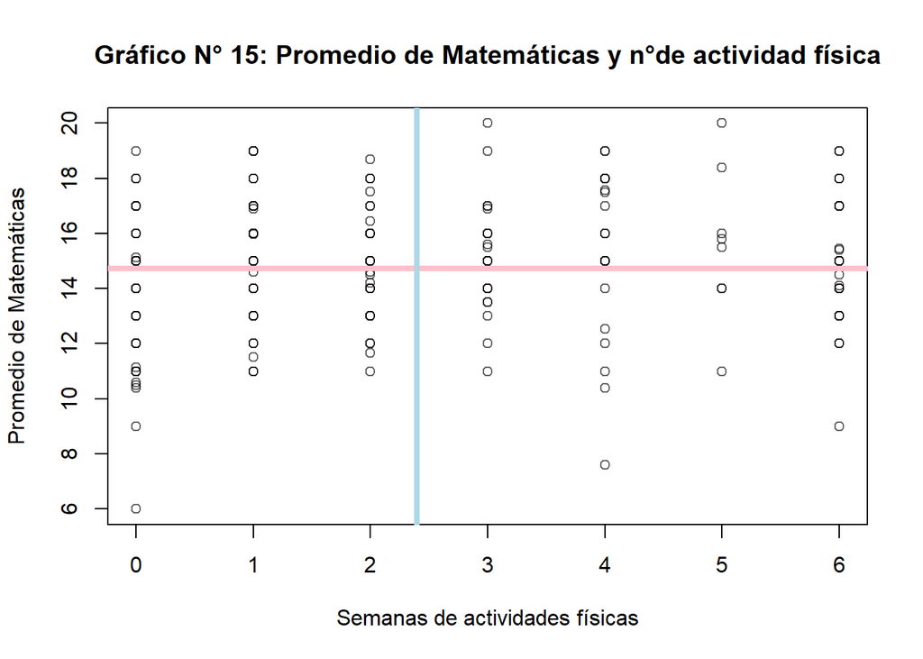

```r
plot(EL$Matemáticas~EL$AFísica,main="Gráfico N° 15: Promedio de Matemáticas y n°de actividad física",xlab="Semanas de actividades físicas",ylab="Promedio de Matemáticas", col = rgb(0, 0, 0, 0.6))

abline(h = mean(EL$Matemáticas, na.rm = T), col = "pink", lwd = 4)
abline(v = mean(EL$AFísica, na.rm = T), col = "lightblue", lwd = 4)
```

##### Gráfico caja N°16 En este gráfico de dispersión se pretende mostrar una relación entre el promedio de las notas de Ciencias y el número de veces de la semana que dedicaron a las actividades físicas.

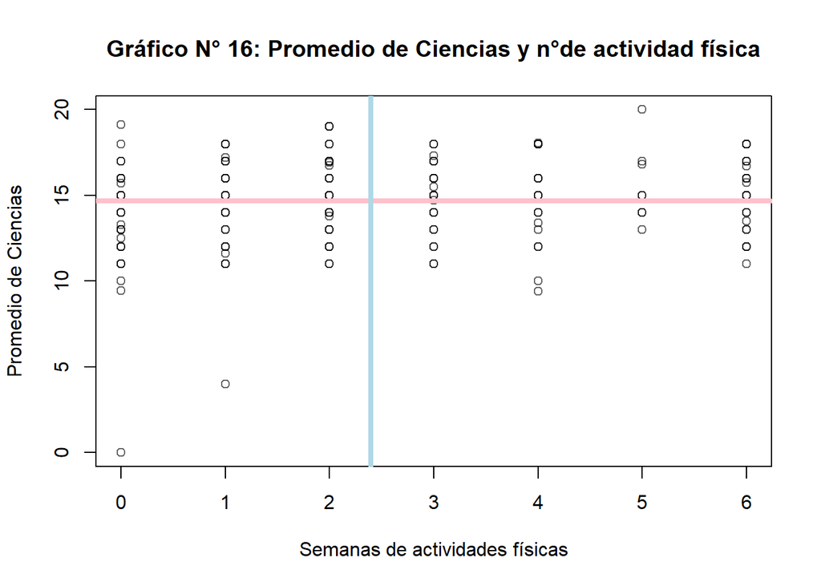

```r
plot(EL$Ciencias~EL$AFísica,main="Gráfico N° 16: Promedio de Ciencias y n°de actividad física",xlab="Semanas de actividades físicas",ylab="Promedio de Ciencias", col = rgb(0, 0, 0, 0.6))

abline(h = mean(EL$Ciencias, na.rm = T), col = "pink", lwd = 4)
abline(v = mean(EL$AFísica, na.rm = T), col = "lightblue", lwd = 4)
```

##### Gráfico caja N°17

En este gráfico de dispersión se pretende mostrar una relación entre el promedio de las notas de Letras y el número de veces de la semana que dedicaron a las actividades físicas.

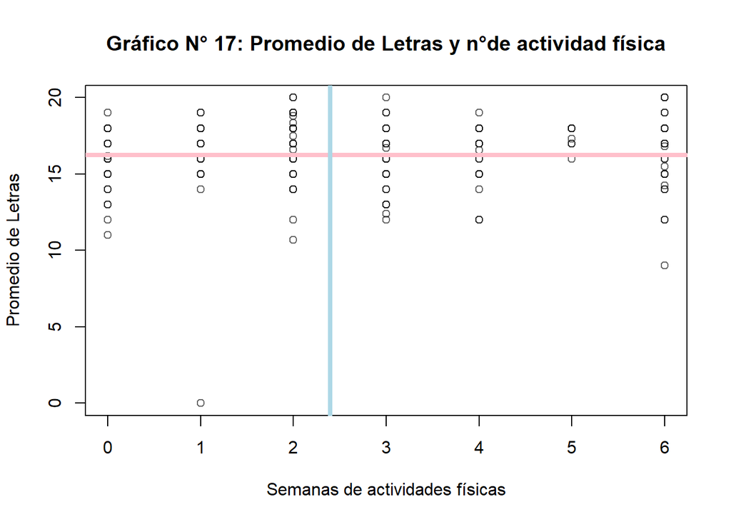

```r
plot(EL$Letras~EL$AFísica,main="Gráfico N° 17: Promedio de Letras y n°de actividad física",xlab="Semanas de actividades físicas",ylab="Promedio de Letras", col = rgb(0, 0, 0, 0.6))

abline(h = mean(EL$Letras, na.rm = T), col = "pink", lwd = 4)
abline(v = mean(EL$AFísica, na.rm = T), col = "lightblue", lwd = 4)
```

## **Determinar si la cantidad de horas de estudio está relacionada directamente con las notas.**

##### Gráfico caja N°18

`r Tiempo <- boxplot(EL$Hora_Estudio, vertical = T, main="Gráfico N° 18: Horas dedicadas al estudio semanal",xlab = "Tiempo (Horas) ", ylab = " ", las = 1, col = "yellow") Tiempo`

`## $stats ## [,1] ## [1,] 1.5 ## [2,] 4.5 ## [3,] 4.5 ## [4,] 9.0 ## [5,] 9.0 ## ## $n ## [1] 204 ## ## $conf ## [,1] ## [1,] 4.0022 ## [2,] 4.9978 ## ## $out ## [1] 18 18 18 18 24 18 24 18 18 18 24 18 18 18 24 18 24 18 24 18 18 24 18 24 24 ## [26] 24 ## ## $group ## [1] 1 1 1 1 1 1 1 1 1 1 1 1 1 1 1 1 1 1 1 1 1 1 1 1 1 1 ## ## $names ## [1] ""`

`r abline(h=1.5,col ="red",lw=2 ) abline(h=4.5,col ="green",lw=2 ) abline(h=9.0,col ="blue", lw=2)`

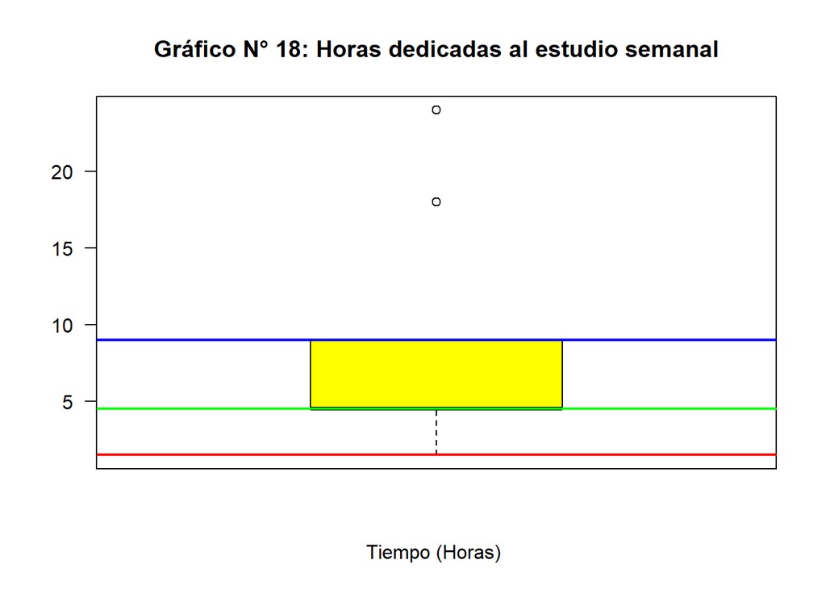

`r # tabla de valores fi=table(EL$Hora_Estudio) pi=round(prop.table(fi)*100,2) cbind(fi,pi)`

`## fi pi ## 1.5 45 22.06 ## 4.5 77 37.75 ## 9 56 27.45 ## 18 16 7.84 ## 24 10 4.90`

`r filtro <- EL$Hora_Estudio >9`

`r mean(EL$Hora_Estudio[!filtro])`

`## [1] 5.157303`

`r median(EL$Hora_Estudio[!filtro])`

`## [1] 4.5`

`r summary(EL$Hora_Estudio)`

`## Min. 1st Qu. Median Mean 3rd Qu. Max. ## 1.500 4.500 4.500 7.088 9.000 24.000` **En el boxplot nos muestra las horas de estudio después de clases, la mayoría de los estudiantes encuestados estudian de 4:30 horas a 9:00 horas aproximadamente a la semana.**

##### Gráfico caja N°19

`r EL$Notas_promedio=round(((EL$Letras+EL$Matemáticas+EL$Ciencias)/3),2)`

`r summary(EL$Notas_promedio) #`

`## Min. 1st Qu. Median Mean 3rd Qu. Max. ## 10.53 14.20 15.33 15.21 16.33 19.33`

`r fi=table(EL$Notas_promedio) pi=round(prop.table(fi)*100,2) cbind(fi,pi)`

`## fi pi ## 10.53 1 0.49 ## 11 1 0.49 ## 11.33 1 0.49 ## 11.67 2 0.98 ## 11.93 1 0.49 ## 12 2 0.98 ## 12.28 1 0.49 ## 12.33 2 0.98 ## 12.65 1 0.49 ## 12.67 1 0.49 ## 13 9 4.41 ## 13.33 6 2.94 ## 13.37 1 0.49 ## 13.5 1 0.49 ## 13.53 1 0.49 ## 13.67 9 4.41 ## 13.83 1 0.49 ## 13.87 1 0.49 ## 14 9 4.41 ## 14.27 1 0.49 ## 14.33 12 5.88 ## 14.37 1 0.49 ## 14.5 1 0.49 ## 14.56 1 0.49 ## 14.67 11 5.39 ## 14.77 2 0.98 ## 14.8 1 0.49 ## 15 15 7.35 ## 15.03 1 0.49 ## 15.04 1 0.49 ## 15.14 1 0.49 ## 15.23 1 0.49 ## 15.33 9 4.41 ## 15.4 1 0.49 ## 15.44 1 0.49 ## 15.48 1 0.49 ## 15.53 1 0.49 ## 15.67 18 8.82 ## 15.73 1 0.49 ## 15.83 1 0.49 ## 15.87 1 0.49 ## 15.93 1 0.49 ## 15.99 1 0.49 ## 16 12 5.88 ## 16.1 1 0.49 ## 16.33 10 4.90 ## 16.53 1 0.49 ## 16.67 10 4.90 ## 16.8 1 0.49 ## 16.82 1 0.49 ## 16.97 1 0.49 ## 17 7 3.43 ## 17.33 8 3.92 ## 17.4 1 0.49 ## 17.54 1 0.49 ## 17.67 4 1.96 ## 18 4 1.96 ## 18.33 2 0.98 ## 18.4 1 0.49 ## 19 1 0.49 ## 19.33 2 0.98`